# Boosting with Cybooster

This notebook demonstrates the usage of the `cybooster` library for boosting various scikit-learn-like (having `fit` and `predict` methods is enough) estimators on different datasets. It includes examples of regression and classification and time series forecasting tasks. It's worth mentioning that only regressors are accepted in `cybooster`, no matter the task.

`cybooster` is a high-performance generic gradient boosting (any based learner can be used) library designed for classification and regression tasks. It is built on Cython (that is, C) for speed and efficiency. This version will also be more GPU friendly, thanks to JAX, making it suitable for large datasets.

In `cybooster`, each base learner is augmented with a randomized neural network (a generalization of https://www.researchgate.net/publication/346059361_LSBoost_gradient_boosted_penalized_nonlinear_least_squares to any base learner), which allows the model to learn complex patterns in the data. The library supports both classification and regression tasks, making it versatile for various machine learning applications.

`cybooster` is born from `mlsauce`, that might be difficult to install on some systems (for now). `cybooster` installation is straightforward.

```python
!pip install cybooster --upgrade --no-cache-dir
```

# 1 - Simple example

```python
from cybooster import BoosterClassifier, BoosterRegressor
from sklearn.datasets import load_iris, load_diabetes, load_breast_cancer, load_digits, load_wine
from sklearn.model_selection import train_test_split
from sklearn.metrics import accuracy_score, mean_squared_error, root_mean_squared_error
from sklearn.linear_model import LinearRegression
from time import time


# Regression Examples
X, y = load_diabetes(return_X_y=True)
X_train, X_test, y_train, y_test = train_test_split(X, y, test_size=0.2, random_state=42)
regressor = BoosterRegressor(obj=LinearRegression(), n_estimators=100, learning_rate=0.1,
                             n_hidden_features=10, verbose=1, seed=42)
start = time()
regressor.fit(X_train, y_train)
y_pred = regressor.predict(X_test)
print(f"Elapsed: {time() - start} s")
rmse = root_mean_squared_error(y_test, y_pred)
print(f"RMSE for regression: {rmse:.4f}")

# Classification Example
X, y = load_iris(return_X_y=True)
X_train, X_test, y_train, y_test = train_test_split(X, y, test_size=0.2, random_state=42)
classifier = BoosterClassifier(obj=LinearRegression(), n_estimators=100, learning_rate=0.1,
                               n_hidden_features=10, verbose=1, seed=42)
start = time()
try:
    classifier.fit(X_train, y_train)
except Exception as e: # this is for Windows users
    y_train = y_train.astype('int32')
    classifier.fit(X_train, y_train)
y_pred = classifier.predict(X_test)
print(f"Elapsed: {time() - start} s")
accuracy = accuracy_score(y_test, y_pred)
print(f"Accuracy for classification: {accuracy:.4f}")

X, y = load_wine(return_X_y=True)
X_train, X_test, y_train, y_test = train_test_split(X, y, test_size=0.2, random_state=42)
classifier = BoosterClassifier(obj=LinearRegression(), n_estimators=100, learning_rate=0.1,
                               n_hidden_features=10, verbose=1, seed=42)
start = time()
try:
    classifier.fit(X_train, y_train)
except Exception as e: # this is for Windows users
    y_train = y_train.astype('int32')
    classifier.fit(X_train, y_train)
y_pred = classifier.predict(X_test)
print(f"Elapsed: {time() - start} s")
accuracy = accuracy_score(y_test, y_pred)
print(f"Accuracy for classification: {accuracy:.4f}")

X, y = load_breast_cancer(return_X_y=True)
X_train, X_test, y_train, y_test = train_test_split(X, y, test_size=0.2, random_state=42)
classifier = BoosterClassifier(obj=LinearRegression(), n_estimators=100, learning_rate=0.1,
                               n_hidden_features=10, verbose=1, seed=42)
start = time()
try:
    classifier.fit(X_train, y_train)
except Exception as e:
    y_train = y_train.astype('int32')
    classifier.fit(X_train, y_train)
y_pred = classifier.predict(X_test)
print(f"Elapsed: {time() - start} s")
accuracy = accuracy_score(y_test, y_pred)
print(f"Accuracy for classification: {accuracy:.4f}")

X, y = load_digits(return_X_y=True)
X_train, X_test, y_train, y_test = train_test_split(X, y, test_size=0.2, random_state=42)
classifier = BoosterClassifier(obj=LinearRegression(), n_estimators=100, learning_rate=0.1,
                               n_hidden_features=10, verbose=1, seed=42)
start = time()
try:
    classifier.fit(X_train, y_train)
except Exception as e:
    y_train = y_train.astype('int32')
    classifier.fit(X_train, y_train)
y_pred = classifier.predict(X_test)
print(f"Elapsed: {time() - start} s")
accuracy = accuracy_score(y_test, y_pred)
print(f"Accuracy for classification: {accuracy:.4f}")
```

```
Elapsed: 0.47596025466918945 s
RMSE for regression: 50.0380
```

```
Elapsed: 0.3156728744506836 s
Accuracy for classification: 1.0000
```

```
Elapsed: 0.40644145011901855 s
Accuracy for classification: 1.0000
```

```
Elapsed: 0.47872471809387207 s
Accuracy for classification: 0.9649
```

```
Elapsed: 7.97456169128418 s
Accuracy for classification: 0.9500
```

# 2 - Loop on models

```python
import pandas as pd
from sklearn.utils import all_estimators
from tqdm import tqdm
from sklearn.utils.multiclass import type_of_target
from sklearn.datasets import fetch_california_housing


# Get all scikit-learn regressors
estimators = all_estimators(type_filter='regressor')

results_regressors = []
results_classifiers = []

verbose = 0

for name, RegressorClass in tqdm(estimators):

    if name in ['MultiOutputRegressor', 'MultiOutputClassifier', 'StackingRegressor', 'StackingClassifier',
                    'VotingRegressor', 'VotingClassifier', 'TransformedTargetRegressor', 'RegressorChain',
                    'GradientBoostingRegressor', 'HistGradientBoostingRegressor', 'RandomForestRegressor',
                    'ExtraTreesRegressor', 'MLPRegressor']:

        continue

    try:
      print(f"\nRunning with {name}")
      # Regression Examples
      X, y = load_diabetes(return_X_y=True)
      X_train, X_test, y_train, y_test = train_test_split(X, y, test_size=0.2, random_state=42)
      regressor = BoosterRegressor(obj=RegressorClass(), n_estimators=100, learning_rate=0.1,
                                  n_hidden_features=10, verbose=verbose, seed=42)
      start = time()
      regressor.fit(X_train, y_train)
      y_pred = regressor.predict(X_test)
      print(f"Elapsed: {time() - start} s")
      rmse = root_mean_squared_error(y_test, y_pred)
      print(f"RMSE for regression: {rmse:.4f}")
      results_regressors.append(["diabetes", name, rmse])

      X, y = fetch_california_housing(return_X_y=True)
      X_train, X_test, y_train, y_test = train_test_split(X[:1000,:], y[:1000], test_size=0.2, random_state=42)
      regressor = BoosterRegressor(obj=RegressorClass(), n_estimators=100, learning_rate=0.1,
                                  n_hidden_features=10, verbose=verbose, seed=42)
      start = time()
      regressor.fit(X_train, y_train)
      y_pred = regressor.predict(X_test)
      print(f"Elapsed: {time() - start} s")
      rmse = root_mean_squared_error(y_test, y_pred)
      print(f"RMSE for regression: {rmse:.4f}")
      results_regressors.append(["housing", name, rmse])

      # Classification Example
      X, y = load_iris(return_X_y=True)
      X_train, X_test, y_train, y_test = train_test_split(X, y, test_size=0.2, random_state=42)
      classifier = BoosterClassifier(obj=RegressorClass(), n_estimators=100, learning_rate=0.1,
                                    n_hidden_features=10, verbose=verbose, seed=42)
      start = time()
      try:
          classifier.fit(X_train, y_train)
      except Exception as e: # this is for Windows users
          y_train = y_train.astype('int32')
          classifier.fit(X_train, y_train)
      y_pred = classifier.predict(X_test)
      print(f"Elapsed: {time() - start} s")
      accuracy = accuracy_score(y_test, y_pred)
      print(f"Accuracy for classification: {accuracy:.4f}")
      results_classifiers.append(["iris", name, accuracy])

      X, y = load_wine(return_X_y=True)
      X_train, X_test, y_train, y_test = train_test_split(X, y, test_size=0.2, random_state=42)
      classifier = BoosterClassifier(obj=RegressorClass(), n_estimators=100, learning_rate=0.1,
                                    n_hidden_features=10, verbose=verbose, seed=42)
      start = time()
      try:
          classifier.fit(X_train, y_train)
      except Exception as e: # this is for Windows users
          y_train = y_train.astype('int32')
          classifier.fit(X_train, y_train)
      y_pred = classifier.predict(X_test)
      print(f"Elapsed: {time() - start} s")
      accuracy = accuracy_score(y_test, y_pred)
      print(f"Accuracy for classification: {accuracy:.4f}")
      results_classifiers.append(["wine", name, accuracy])

      X, y = load_breast_cancer(return_X_y=True)
      X_train, X_test, y_train, y_test = train_test_split(X, y, test_size=0.2, random_state=42)
      classifier = BoosterClassifier(obj=RegressorClass(), n_estimators=100, learning_rate=0.1,
                                    n_hidden_features=10, verbose=verbose, seed=42)
      start = time()
      try:
          classifier.fit(X_train, y_train)
      except Exception as e:
          y_train = y_train.astype('int32')
          classifier.fit(X_train, y_train)
      y_pred = classifier.predict(X_test)
      print(f"Elapsed: {time() - start} s")
      accuracy = accuracy_score(y_test, y_pred)
      print(f"Accuracy for classification: {accuracy:.4f}")
      results_classifiers.append(["breast_cancer", name, accuracy])

      X, y = load_digits(return_X_y=True)
      X_train, X_test, y_train, y_test = train_test_split(X, y, test_size=0.2, random_state=42)
      classifier = BoosterClassifier(obj=RegressorClass(), n_estimators=100, learning_rate=0.1,
                                    n_hidden_features=10, verbose=verbose, seed=42)
      start = time()
      try:
          classifier.fit(X_train, y_train)
      except Exception as e:
          y_train = y_train.astype('int32')
          classifier.fit(X_train, y_train)
      y_pred = classifier.predict(X_test)
      print(f"Elapsed: {time() - start} s")
      accuracy = accuracy_score(y_test, y_pred)
      print(f"Accuracy for classification: {accuracy:.4f}")
      results_classifiers.append(["digits", name, accuracy])
    except Exception as e:
      continue
```

```
Running with ARDRegression
Elapsed: 4.067568063735962 s
RMSE for regression: 50.7652
```

```
Elapsed: 0.5349180698394775 s
RMSE for regression: 0.4230

Running with AdaBoostRegressor
Elapsed: 13.95115351676941 s
RMSE for regression: 52.9127
```

```
Elapsed: 21.075905323028564 s
RMSE for regression: 0.3281

Running with BaggingRegressor
Elapsed: 7.636256456375122 s
RMSE for regression: 54.6999
Elapsed: 19.565755367279053 s
RMSE for regression: 0.3489
Elapsed: 4.050839185714722 s
Accuracy for classification: 1.0000
Elapsed: 4.740557432174683 s
Accuracy for classification: 0.9722
Elapsed: 30.266514778137207 s
Accuracy for classification: 0.9561
```

```
Elapsed: 70.22430944442749 s
Accuracy for classification: 0.9667

Running with BayesianRidge
Elapsed: 0.4146571159362793 s
RMSE for regression: 50.7598
```

```
Elapsed: 0.43773674964904785 s
RMSE for regression: 0.4328

Running with CCA

Running with DecisionTreeRegressor
Elapsed: 0.7410914897918701 s
RMSE for regression: 61.0645
Elapsed: 1.557697057723999 s
RMSE for regression: 0.3849
Elapsed: 0.17411327362060547 s
Accuracy for classification: 1.0000
Elapsed: 0.23183941841125488 s
Accuracy for classification: 0.9444
Elapsed: 1.1447832584381104 s
Accuracy for classification: 0.9386
```

```
Elapsed: 6.3166093826293945 s
Accuracy for classification: 0.8583

Running with DummyRegressor
Elapsed: 0.002477407455444336 s
RMSE for regression: 73.2225
Elapsed: 0.0028095245361328125 s
RMSE for regression: 0.8700
Elapsed: 0.002324819564819336 s
Accuracy for classification: 0.3000
Elapsed: 0.0029370784759521484 s
Accuracy for classification: 0.3889
Elapsed: 0.002457141876220703 s
Accuracy for classification: 0.6228
Elapsed: 0.006379127502441406 s
Accuracy for classification: 0.0778

Running with ElasticNet
Elapsed: 0.21411395072937012 s
RMSE for regression: 50.7735
Elapsed: 0.06587982177734375 s
RMSE for regression: 0.7325
Elapsed: 0.004933595657348633 s
Accuracy for classification: 0.3000
Elapsed: 0.018543004989624023 s
Accuracy for classification: 0.5000
Elapsed: 0.07728099822998047 s
Accuracy for classification: 0.8246
```

```
Elapsed: 0.01873159408569336 s
Accuracy for classification: 0.0778

Running with ElasticNetCV
```

```
Elapsed: 2.569856882095337 s
RMSE for regression: 51.2435
```

[output not shown]

[output cut: 14 more lines]

```
Elapsed: 5.964995384216309 s
RMSE for regression: 0.4343

Running with ExtraTreeRegressor
Elapsed: 0.5135252475738525 s
RMSE for regression: 55.0715
Elapsed: 0.8700869083404541 s
RMSE for regression: 0.3468
Elapsed: 0.23128819465637207 s
Accuracy for classification: 0.9333
Elapsed: 0.24360942840576172 s
Accuracy for classification: 1.0000
Elapsed: 0.404954195022583 s
Accuracy for classification: 0.9649
```

```
Elapsed: 1.7572131156921387 s
Accuracy for classification: 0.9750

Running with GammaRegressor

Running with GaussianProcessRegressor
Elapsed: 2.515669107437134 s
RMSE for regression: 66.6183
Elapsed: 21.384825706481934 s
RMSE for regression: 0.5012
Elapsed: 1.1286356449127197 s
Accuracy for classification: 1.0000
Elapsed: 0.8197286128997803 s
Accuracy for classification: 0.8333
Elapsed: 6.324432849884033 s
Accuracy for classification: 0.6316
```

```
Elapsed: 104.5441346168518 s
Accuracy for classification: 0.2278

Running with HuberRegressor
```

[output not shown]

[output cut: 467 more lines]

[output not shown]

```
Elapsed: 6.84102463722229 s
RMSE for regression: 50.3546
```

[output not shown]

[output cut: 96 more lines]

[output not shown]

```
Elapsed: 4.643861532211304 s
RMSE for regression: 0.3731

Running with IsotonicRegression

Running with KNeighborsRegressor
Elapsed: 0.4125041961669922 s
RMSE for regression: 219.8186
Elapsed: 0.8057188987731934 s
RMSE for regression: 1.0007
Elapsed: 0.2951483726501465 s
Accuracy for classification: 1.0000
Elapsed: 0.2155454158782959 s
Accuracy for classification: 0.9722
Elapsed: 0.48292994499206543 s
Accuracy for classification: 0.8860
```

```
Elapsed: 7.595134258270264 s
Accuracy for classification: 0.9583

Running with KernelRidge
Elapsed: 3.8773553371429443 s
RMSE for regression: 50.1380
Elapsed: 8.994706153869629 s
RMSE for regression: 0.4238
Elapsed: 0.26732659339904785 s
Accuracy for classification: 0.9333
Elapsed: 2.3327672481536865 s
Accuracy for classification: 1.0000
Elapsed: 2.790550470352173 s
Accuracy for classification: 0.9649
```

```
Elapsed: 25.78620409965515 s
Accuracy for classification: 0.9528

Running with Lars
Elapsed: 0.49329423904418945 s
RMSE for regression: 249.1971
Elapsed: 0.4653139114379883 s
RMSE for regression: 0.5482
```

[output not shown]

[output cut: 113 more lines]

[output not shown]

```
Elapsed: 1.0182015895843506 s
Accuracy for classification: 0.2667
Elapsed: 1.2435550689697266 s
Accuracy for classification: 0.7778
```

[output not shown]

[output cut: 41 more lines]

[output not shown]

```
Elapsed: 2.609036684036255 s
Accuracy for classification: 0.5263
```

```
Elapsed: 18.63607382774353 s
Accuracy for classification: 0.3000

Running with LarsCV
```

```
Elapsed: 0.5618622303009033 s
RMSE for regression: 52.9366
```

```
Elapsed: 0.8049659729003906 s
RMSE for regression: 0.4644

Running with Lasso
Elapsed: 0.12689447402954102 s
RMSE for regression: 50.4909
Elapsed: 0.0041234493255615234 s
RMSE for regression: 0.8700
Elapsed: 0.003805398941040039 s
Accuracy for classification: 0.3000
Elapsed: 0.0037839412689208984 s
Accuracy for classification: 0.3889
```

```
Elapsed: 0.05577516555786133 s
Accuracy for classification: 0.8158
Elapsed: 0.01977252960205078 s
Accuracy for classification: 0.0778

Running with LassoCV
```

[output not shown]

[output cut: 103 more lines]

[output not shown]

```
Elapsed: 4.114358425140381 s
RMSE for regression: 51.3331
```

[output not shown]

[output cut: 19 more lines]

```
Elapsed: 6.785216331481934 s
RMSE for regression: 0.4348

Running with LassoLars
```

```
Elapsed: 0.20097756385803223 s
RMSE for regression: 50.4911
Elapsed: 0.004069805145263672 s
RMSE for regression: 0.8700
Elapsed: 0.0033965110778808594 s
Accuracy for classification: 0.3000
Elapsed: 0.003522157669067383 s
Accuracy for classification: 0.3889
Elapsed: 0.09224557876586914 s
Accuracy for classification: 0.8158
Elapsed: 0.014913558959960938 s
Accuracy for classification: 0.0778

Running with LassoLarsCV
Elapsed: 0.5652470588684082 s
RMSE for regression: 51.6581
```

```
Elapsed: 1.2313728332519531 s
RMSE for regression: 0.4311

Running with LassoLarsIC
Elapsed: 0.2026379108428955 s
RMSE for regression: 50.8669
```

```
Elapsed: 0.33669328689575195 s
RMSE for regression: 0.4233

Running with LinearRegression
Elapsed: 0.19397854804992676 s
RMSE for regression: 50.0380
Elapsed: 0.25861597061157227 s
RMSE for regression: 0.3969
Elapsed: 0.1840972900390625 s
Accuracy for classification: 1.0000
Elapsed: 0.17545342445373535 s
Accuracy for classification: 1.0000
Elapsed: 0.3274402618408203 s
Accuracy for classification: 0.9649
```

```
Elapsed: 3.6779396533966064 s
Accuracy for classification: 0.9500

Running with LinearSVR
Elapsed: 0.28504157066345215 s
RMSE for regression: 49.1958
```

[output not shown]

[output cut: 146 more lines]

[output not shown]

```
Elapsed: 4.671899795532227 s
RMSE for regression: 0.3761

Running with MultiTaskElasticNet

Running with MultiTaskElasticNetCV

Running with MultiTaskLasso

Running with MultiTaskLassoCV

Running with NuSVR
Elapsed: 1.2875077724456787 s
RMSE for regression: 51.9660
```

```
Elapsed: 9.450008869171143 s
RMSE for regression: 0.3469

Running with OrthogonalMatchingPursuit
Elapsed: 0.16147136688232422 s
RMSE for regression: 50.7979
Elapsed: 0.17341041564941406 s
RMSE for regression: 0.4546
Elapsed: 0.1641554832458496 s
Accuracy for classification: 0.9667
Elapsed: 0.20760297775268555 s
Accuracy for classification: 1.0000
Elapsed: 0.330524206161499 s
Accuracy for classification: 0.9825
```

```
Elapsed: 0.996509313583374 s
Accuracy for classification: 0.9583

Running with OrthogonalMatchingPursuitCV
Elapsed: 0.63850998878479 s
RMSE for regression: 50.7995
```

```
Elapsed: 0.7047955989837646 s
RMSE for regression: 0.4388

Running with PLSCanonical

Running with PLSRegression
Elapsed: 0.21582293510437012 s
RMSE for regression: 49.8776
Elapsed: 0.24137067794799805 s
RMSE for regression: 0.4261
Elapsed: 0.24464106559753418 s
Accuracy for classification: 1.0000
Elapsed: 0.2733957767486572 s
Accuracy for classification: 1.0000
Elapsed: 0.2548189163208008 s
Accuracy for classification: 0.9737
```

```
Elapsed: 3.1161069869995117 s
Accuracy for classification: 0.9306

Running with PassiveAggressiveRegressor
Elapsed: 0.18162250518798828 s
RMSE for regression: 49.0170
```

```
Elapsed: 0.2270033359527588 s
RMSE for regression: 0.4127

Running with PoissonRegressor

Running with QuantileRegressor
Elapsed: 3.2531702518463135 s
RMSE for regression: 72.8862
```

```
Elapsed: 6.122649192810059 s
RMSE for regression: 0.8528

Running with RANSACRegressor
Elapsed: 12.880609035491943 s
RMSE for regression: 58.8836
Elapsed: 12.161862134933472 s
RMSE for regression: 0.4726
```

```
Elapsed: 11.872267007827759 s
Accuracy for classification: 0.5000
Elapsed: 13.281305074691772 s
Accuracy for classification: 0.3889
Elapsed: 15.801233768463135 s
Accuracy for classification: 0.8421
```

```
Elapsed: 208.6714358329773 s
Accuracy for classification: 0.5306

Running with RadiusNeighborsRegressor
```

[output not shown]

[output cut: 146 more lines]

[output not shown]

```
Elapsed: 0.9109394550323486 s

Running with Ridge
Elapsed: 0.17456555366516113 s
RMSE for regression: 50.1804
Elapsed: 0.19010615348815918 s
RMSE for regression: 0.3978
Elapsed: 0.1613008975982666 s
Accuracy for classification: 1.0000
Elapsed: 0.18721652030944824 s
Accuracy for classification: 1.0000
Elapsed: 0.3114893436431885 s
Accuracy for classification: 0.9649
```

```
Elapsed: 0.601301908493042 s
Accuracy for classification: 0.9500

Running with RidgeCV
Elapsed: 0.2643613815307617 s
RMSE for regression: 50.1530
Elapsed: 0.42165279388427734 s
RMSE for regression: 0.4030
Elapsed: 0.24331355094909668 s
Accuracy for classification: 1.0000
Elapsed: 0.25229525566101074 s
Accuracy for classification: 1.0000
Elapsed: 2.254711627960205 s
Accuracy for classification: 0.9649
```

```
Elapsed: 5.993970155715942 s
Accuracy for classification: 0.9500

Running with SGDRegressor
Elapsed: 0.21875286102294922 s
RMSE for regression: 49.7408
```

```
Elapsed: 0.2683231830596924 s
RMSE for regression: 0.4215

Running with SVR
Elapsed: 1.8788957595825195 s
RMSE for regression: 49.4323
```

```
Elapsed: 8.855087757110596 s
RMSE for regression: 0.3460

Running with TheilSenRegressor
Elapsed: 153.34134554862976 s
RMSE for regression: 49.0028
```

```
Elapsed: 143.07517862319946 s
RMSE for regression: 0.3840

Running with TweedieRegressor
Elapsed: 0.6265287399291992 s
RMSE for regression: 50.5897
```

```
Elapsed: 0.4339334964752197 s
RMSE for regression: 0.4447
```

```python
df_results_regressors = pd.DataFrame(results_regressors, columns=['Dataset', 'Model', 'RMSE'])
df_results_regressors.sort_values(by='RMSE', ascending=True, inplace=True)

df_results_classifiers = pd.DataFrame(results_classifiers, columns=['Dataset', 'Model', 'Accuracy'])
df_results_classifiers.sort_values(by='Accuracy', ascending=False, inplace=True)

df_results_regressors_diabetes = df_results_regressors[df_results_regressors['Dataset'] == 'diabetes']
df_results_regressors_housing = df_results_regressors[df_results_regressors['Dataset'] == 'housing']
df_results_classifiers_iris = df_results_classifiers[df_results_classifiers['Dataset'] == 'iris']
df_results_classifiers_wine = df_results_classifiers[df_results_classifiers['Dataset'] == 'wine']
df_results_classifiers_breast_cancer = df_results_classifiers[df_results_classifiers['Dataset'] == 'breast_cancer']
df_results_classifiers_digits = df_results_classifiers[df_results_classifiers['Dataset'] == 'digits']

print("Best regressors:")
display(df_results_regressors_diabetes)
display(df_results_regressors_housing)

print("\nBest classifiers:")
display(df_results_classifiers_iris)
display(df_results_classifiers_wine)
display(df_results_classifiers_breast_cancer)
display(df_results_classifiers_digits)
```

```
Best regressors:
```

|  | Dataset | Model | RMSE |
| --- | --- | --- | --- |
| 66 | diabetes | TheilSenRegressor | 49.002812 |
| 52 | diabetes | PassiveAggressiveRegressor | 49.017006 |
| 42 | diabetes | LinearSVR | 49.195826 |
| 64 | diabetes | SVR | 49.432314 |
| 62 | diabetes | SGDRegressor | 49.740770 |
| 50 | diabetes | PLSRegression | 49.877624 |
| 40 | diabetes | LinearRegression | 50.038024 |
| 24 | diabetes | KernelRidge | 50.137963 |
| 60 | diabetes | RidgeCV | 50.153038 |
| 58 | diabetes | Ridge | 50.180423 |
| 20 | diabetes | HuberRegressor | 50.354598 |
| 30 | diabetes | Lasso | 50.490869 |
| 34 | diabetes | LassoLars | 50.491092 |
| 68 | diabetes | TweedieRegressor | 50.589740 |
| 6 | diabetes | BayesianRidge | 50.759803 |
| 0 | diabetes | ARDRegression | 50.765231 |
| 12 | diabetes | ElasticNet | 50.773545 |
| 46 | diabetes | OrthogonalMatchingPursuit | 50.797879 |
| 48 | diabetes | OrthogonalMatchingPursuitCV | 50.799486 |
| 38 | diabetes | LassoLarsIC | 50.866918 |
| 14 | diabetes | ElasticNetCV | 51.243455 |
| 32 | diabetes | LassoCV | 51.333102 |
| 36 | diabetes | LassoLarsCV | 51.658117 |
| 44 | diabetes | NuSVR | 51.965976 |
| 2 | diabetes | AdaBoostRegressor | 52.912706 |
| 28 | diabetes | LarsCV | 52.936573 |
| 4 | diabetes | BaggingRegressor | 54.699888 |
| 16 | diabetes | ExtraTreeRegressor | 55.071533 |
| 56 | diabetes | RANSACRegressor | 58.883571 |
| 8 | diabetes | DecisionTreeRegressor | 61.064470 |
| 18 | diabetes | GaussianProcessRegressor | 66.618258 |
| 54 | diabetes | QuantileRegressor | 72.886227 |
| 10 | diabetes | DummyRegressor | 73.222493 |
| 22 | diabetes | KNeighborsRegressor | 219.818565 |
| 26 | diabetes | Lars | 249.197131 |

|  | Dataset | Model | RMSE |
| --- | --- | --- | --- |
| 3 | housing | AdaBoostRegressor | 0.328082 |
| 65 | housing | SVR | 0.345998 |
| 17 | housing | ExtraTreeRegressor | 0.346823 |
| 45 | housing | NuSVR | 0.346886 |
| 5 | housing | BaggingRegressor | 0.348871 |
| 21 | housing | HuberRegressor | 0.373068 |
| 43 | housing | LinearSVR | 0.376118 |
| 67 | housing | TheilSenRegressor | 0.384006 |
| 9 | housing | DecisionTreeRegressor | 0.384891 |
| 41 | housing | LinearRegression | 0.396910 |
| 59 | housing | Ridge | 0.397799 |
| 61 | housing | RidgeCV | 0.402997 |
| 53 | housing | PassiveAggressiveRegressor | 0.412686 |
| 63 | housing | SGDRegressor | 0.421484 |
| 1 | housing | ARDRegression | 0.423014 |
| 39 | housing | LassoLarsIC | 0.423339 |
| 25 | housing | KernelRidge | 0.423757 |
| 51 | housing | PLSRegression | 0.426112 |
| 37 | housing | LassoLarsCV | 0.431140 |
| 7 | housing | BayesianRidge | 0.432840 |
| 15 | housing | ElasticNetCV | 0.434310 |
| 33 | housing | LassoCV | 0.434807 |
| 49 | housing | OrthogonalMatchingPursuitCV | 0.438809 |
| 69 | housing | TweedieRegressor | 0.444735 |
| 47 | housing | OrthogonalMatchingPursuit | 0.454569 |
| 29 | housing | LarsCV | 0.464425 |
| 57 | housing | RANSACRegressor | 0.472617 |
| 19 | housing | GaussianProcessRegressor | 0.501228 |
| 27 | housing | Lars | 0.548208 |
| 13 | housing | ElasticNet | 0.732468 |
| 55 | housing | QuantileRegressor | 0.852777 |
| 35 | housing | LassoLars | 0.869965 |
| 11 | housing | DummyRegressor | 0.869965 |
| 31 | housing | Lasso | 0.869965 |
| 23 | housing | KNeighborsRegressor | 1.000700 |

```
Best classifiers:
```

|  | Dataset | Model | Accuracy |
| --- | --- | --- | --- |
| 0 | iris | BaggingRegressor | 1.000000 |
| 24 | iris | KNeighborsRegressor | 1.000000 |
| 4 | iris | DecisionTreeRegressor | 1.000000 |
| 52 | iris | PLSRegression | 1.000000 |
| 20 | iris | GaussianProcessRegressor | 1.000000 |
| 44 | iris | LinearRegression | 1.000000 |
| 64 | iris | RidgeCV | 1.000000 |
| 60 | iris | Ridge | 1.000000 |
| 48 | iris | OrthogonalMatchingPursuit | 0.966667 |
| 28 | iris | KernelRidge | 0.933333 |
| 16 | iris | ExtraTreeRegressor | 0.933333 |
| 56 | iris | RANSACRegressor | 0.500000 |
| 12 | iris | ElasticNet | 0.300000 |
| 8 | iris | DummyRegressor | 0.300000 |
| 40 | iris | LassoLars | 0.300000 |
| 36 | iris | Lasso | 0.300000 |
| 32 | iris | Lars | 0.266667 |

|  | Dataset | Model | Accuracy |
| --- | --- | --- | --- |
| 17 | wine | ExtraTreeRegressor | 1.000000 |
| 53 | wine | PLSRegression | 1.000000 |
| 61 | wine | Ridge | 1.000000 |
| 29 | wine | KernelRidge | 1.000000 |
| 49 | wine | OrthogonalMatchingPursuit | 1.000000 |
| 65 | wine | RidgeCV | 1.000000 |
| 45 | wine | LinearRegression | 1.000000 |
| 1 | wine | BaggingRegressor | 0.972222 |
| 25 | wine | KNeighborsRegressor | 0.972222 |
| 5 | wine | DecisionTreeRegressor | 0.944444 |
| 21 | wine | GaussianProcessRegressor | 0.833333 |
| 33 | wine | Lars | 0.777778 |
| 13 | wine | ElasticNet | 0.500000 |
| 37 | wine | Lasso | 0.388889 |
| 41 | wine | LassoLars | 0.388889 |
| 57 | wine | RANSACRegressor | 0.388889 |
| 9 | wine | DummyRegressor | 0.388889 |

|  | Dataset | Model | Accuracy |
| --- | --- | --- | --- |
| 50 | breast_cancer | OrthogonalMatchingPursuit | 0.982456 |
| 54 | breast_cancer | PLSRegression | 0.973684 |
| 30 | breast_cancer | KernelRidge | 0.964912 |
| 66 | breast_cancer | RidgeCV | 0.964912 |
| 46 | breast_cancer | LinearRegression | 0.964912 |
| 62 | breast_cancer | Ridge | 0.964912 |
| 18 | breast_cancer | ExtraTreeRegressor | 0.964912 |
| 2 | breast_cancer | BaggingRegressor | 0.956140 |
| 6 | breast_cancer | DecisionTreeRegressor | 0.938596 |
| 26 | breast_cancer | KNeighborsRegressor | 0.885965 |
| 58 | breast_cancer | RANSACRegressor | 0.842105 |
| 14 | breast_cancer | ElasticNet | 0.824561 |
| 38 | breast_cancer | Lasso | 0.815789 |
| 42 | breast_cancer | LassoLars | 0.815789 |
| 22 | breast_cancer | GaussianProcessRegressor | 0.631579 |
| 10 | breast_cancer | DummyRegressor | 0.622807 |
| 34 | breast_cancer | Lars | 0.526316 |

|  | Dataset | Model | Accuracy |
| --- | --- | --- | --- |
| 19 | digits | ExtraTreeRegressor | 0.975000 |
| 3 | digits | BaggingRegressor | 0.966667 |
| 51 | digits | OrthogonalMatchingPursuit | 0.958333 |
| 27 | digits | KNeighborsRegressor | 0.958333 |
| 31 | digits | KernelRidge | 0.952778 |
| 47 | digits | LinearRegression | 0.950000 |
| 63 | digits | Ridge | 0.950000 |
| 67 | digits | RidgeCV | 0.950000 |
| 55 | digits | PLSRegression | 0.930556 |
| 7 | digits | DecisionTreeRegressor | 0.858333 |
| 59 | digits | RANSACRegressor | 0.530556 |
| 35 | digits | Lars | 0.300000 |
| 23 | digits | GaussianProcessRegressor | 0.227778 |
| 11 | digits | DummyRegressor | 0.077778 |
| 15 | digits | ElasticNet | 0.077778 |
| 39 | digits | Lasso | 0.077778 |
| 43 | digits | LassoLars | 0.077778 |

# 3 - Time series forecasting using `nnetsauce.MTS`

```python
!pip install nnetsauce
```

```
Running with ARDRegression
```

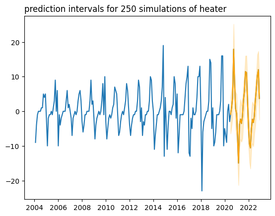

```
Running with BaggingRegressor
```

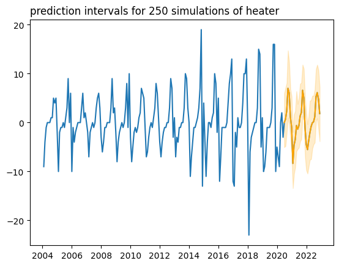

```
Running with BayesianRidge
```

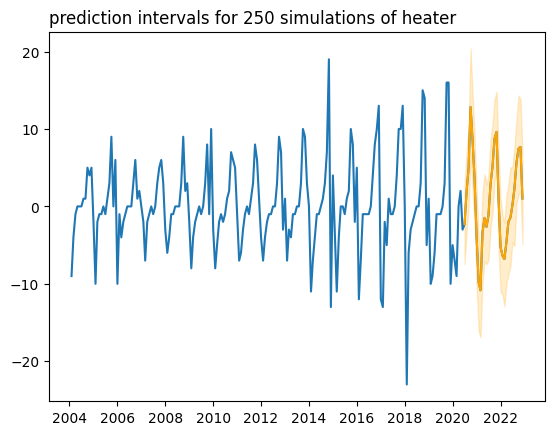

```
Running with CCA
`n_components` upper bound is 1. Got 2 instead. Reduce `n_components`.

Running with DecisionTreeRegressor
```

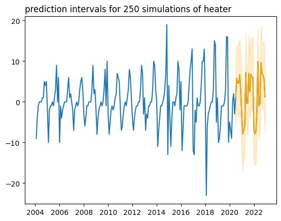

```
Running with DummyRegressor
```

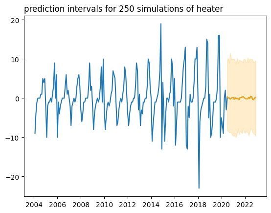

```
Running with ElasticNet
```

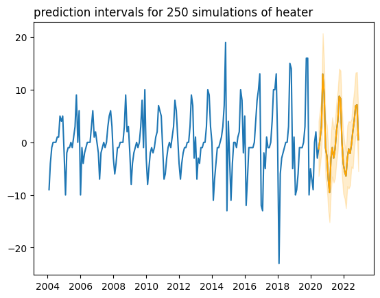

```
Running with ElasticNetCV
```

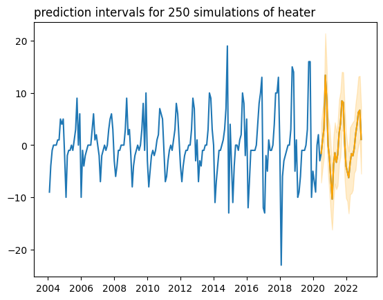

```
Running with ExtraTreeRegressor
```

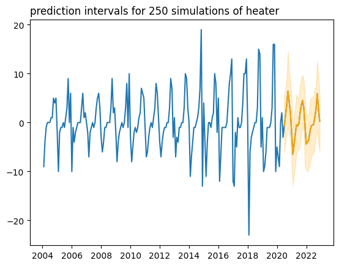

```
Running with GammaRegressor
Some value(s) of y are out of the valid range of the loss 'HalfGammaLoss'.

Running with GaussianProcessRegressor
```

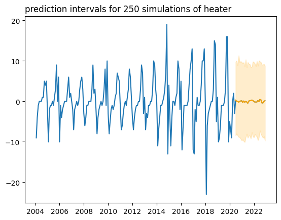

```
Running with HuberRegressor
```

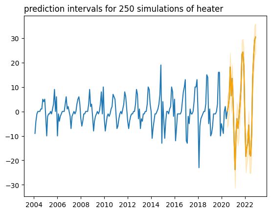

```
Running with IsotonicRegression
Isotonic regression input X should be a 1d array or 2d array with 1 feature

Running with KNeighborsRegressor
```

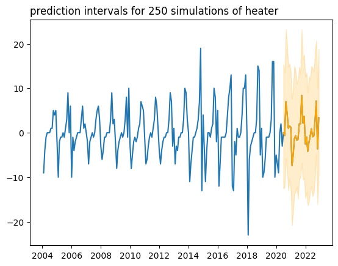

```
Running with KernelRidge
```

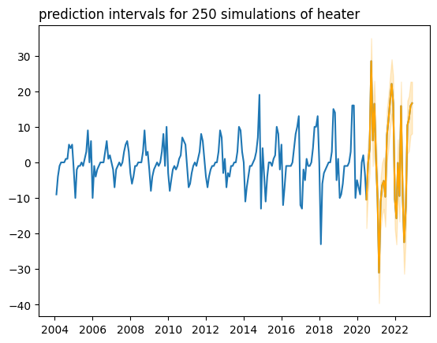

```
Running with Lars
```

```
Input y contains NaN.

Running with LarsCV
```

[20 more figures not shown]

```python
import nnetsauce as ns
import pandas as pd
from sklearn.utils import all_estimators
from tqdm import tqdm
from sklearn.utils.multiclass import type_of_target
from sklearn.datasets import fetch_california_housing


# Get all scikit-learn regressors
estimators = all_estimators(type_filter='regressor')

results_regressors = []
results_classifiers = []

verbose = 0

url = "https://raw.githubusercontent.com/Techtonique/"
url += "datasets/main/time_series/multivariate/"
url += "ice_cream_vs_heater.csv"
df_temp = pd.read_csv(url)
df_temp.index = pd.DatetimeIndex(df_temp.date)
# must have# first other difference
df_icecream = df_temp.drop(columns=['date']).diff().dropna()

for name, RegressorClass in tqdm(estimators):

    if name in ['AdaBoostRegressor', 'MultiOutputRegressor', 'MultiOutputClassifier', 'StackingRegressor', 'StackingClassifier',
                    'VotingRegressor', 'VotingClassifier', 'TransformedTargetRegressor', 'RegressorChain',
                    'GradientBoostingRegressor', 'HistGradientBoostingRegressor', 'RandomForestRegressor',
                    'ExtraTreesRegressor', 'MLPRegressor', 'TheilSenRegressor']:

        continue

    try:
      print(f"\nRunning with {name}")
      # Regression Examples
      mdl = BoosterRegressor(obj=RegressorClass(), n_estimators=100, learning_rate=0.1,
                                  n_hidden_features=10, verbose=verbose, seed=42)
      regr = ns.MTS(obj=mdl,
                    type_pi="scp2-kde",
                    replications=250,
                    lags=20,
                    show_progress=False)
      regr.fit(df_icecream)
      regr.predict(h=30)
      regr.plot("heater", type_plot="pi")
    except Exception as e:
      print(e)
      continue
```